# Text Analysis

The aim of this Markdown is to demonstrate the use of various text analysis tools in R, including text clustering, word clouds and sentiment analysis.

## Data Description

Here, we have a list of 47 classical books which we obtain from the Gutenberg project (www.gutenberg.org). These classical works include War and Peace, Jane Eyre, Moby Dick, Les Miserables, and many others, which are listed later on in this document.

First, let’s load the required `R` libraries.

```r
library(wordcloud)
#library(rJava)
#library(text)
library(tm)
library(SnowballC)
library(words)
library(NbClust)
library(stringr)
library(dplyr)
library(syuzhet)
```

Now, it’s time to load and preprocess the text of the books from www.gutenberg.org.

```r
# Define the URLs of the text documents
urls <- c(
  "https://www.gutenberg.org/cache/epub/2600/pg2600.txt",
  "https://www.gutenberg.org/files/2554/2554-0.txt",
  "https://www.gutenberg.org/cache/epub/42671/pg42671.txt",
  "https://www.gutenberg.org/files/98/98-0.txt",
  "https://www.gutenberg.org/cache/epub/158/pg158.txt",
  "https://www.gutenberg.org/cache/epub/28054/pg28054.txt",
  "https://www.gutenberg.org/cache/epub/1260/pg1260.txt",
  "https://www.gutenberg.org/cache/epub/64317/pg64317.txt",
  "https://www.gutenberg.org/cache/epub/768/pg768.txt",
  "https://www.gutenberg.org/files/2701/2701-0.txt",
  "https://www.gutenberg.org/cache/epub/215/pg215.txt",
  "https://www.gutenberg.org/cache/epub/84/pg84.txt",
  "https://www.gutenberg.org/cache/epub/514/pg514.txt",
  "https://www.gutenberg.org/cache/epub/599/pg599.txt",
  "https://www.gutenberg.org/cache/epub/1399/pg1399.txt",
  "https://www.gutenberg.org/cache/epub/1184/pg1184.txt",
  "https://www.gutenberg.org/files/1400/1400-0.txt",
  "https://www.gutenberg.org/files/135/135-0.txt",
  "https://www.gutenberg.org/cache/epub/345/pg345.txt",
  "https://www.gutenberg.org/files/2413/2413-0.txt",
  "https://www.gutenberg.org/cache/epub/996/pg996.txt",
  "https://www.gutenberg.org/files/65473/65473-0.txt",
  "https://www.gutenberg.org/cache/epub/76/pg76.txt",
  "https://www.gutenberg.org/cache/epub/4078/pg4078.txt",
  "https://www.gutenberg.org/cache/epub/910/pg910.txt",
  "https://www.gutenberg.org/files/24022/24022-0.txt",
  "https://www.gutenberg.org/files/2638/2638-0.txt",
  "https://www.gutenberg.org/files/35/35-0.txt",
  "https://www.gutenberg.org/cache/epub/541/pg541.txt",
  "https://www.gutenberg.org/cache/epub/351/pg351.txt",
  "https://www.gutenberg.org/cache/epub/26/pg26.txt",
  "https://www.gutenberg.org/cache/epub/70841/pg70841.txt",
  "https://www.gutenberg.org/cache/epub/19942/pg19942.txt",
  "https://www.gutenberg.org/files/940/940-0.txt",
  "https://www.gutenberg.org/files/1081/1081-0.txt",
  "https://www.gutenberg.org/cache/epub/25344/pg25344.txt",
  "https://www.gutenberg.org/cache/epub/27780/pg27780.txt",
  "https://www.gutenberg.org/files/4300/4300-0.txt",
  "https://www.gutenberg.org/cache/epub/7849/pg7849.txt",
  "https://www.gutenberg.org/cache/epub/1257/pg1257.txt",
  "https://www.gutenberg.org/files/5200/5200-0.txt",
  "https://www.gutenberg.org/cache/epub/63203/pg63203.txt",
  "https://www.gutenberg.org/cache/epub/1232/pg1232.txt",
  "https://www.gutenberg.org/files/3207/3207-0.txt",
  "https://www.gutenberg.org/cache/epub/766/pg766.txt",
  "https://www.gutenberg.org/cache/epub/2610/pg2610.txt",
  "https://www.gutenberg.org/files/2130/2130-0.txt"
)
```

## Data Preprocessing

The first thing we want to do is to convert the text in all of these URLS into a Corpus. A text corpus (plural: *corpora*) “is a large and unstructured set of texts (nowadays usually electronically stored and processed) used to do statistical analysis and hypothesis testing, checking occurrences or validating linguistic rules within a specific language territory.”

```r
# Load and preprocess all text documents
myCorpus <- tm::VCorpus(VectorSource(sapply(urls, readLines)))

# Convert everything to lower case
myCorpus <- tm_map(myCorpus, content_transformer(tolower))
```

Let’s look at lines 980-1000 of the first entry (document) in the corpus, which happens to be Tolstoy’s War and Peace. (The first 600 or so lines include information about the ebook, and the Table of Contents.)

```r
cat(content(myCorpus[[1]])[980:1000], sep = "\n")
```

```
## beautiful.”
##
## the prince bowed to signify his respect and gratitude.
##
## “i often think,” she continued after a short pause, drawing nearer
## to the prince and smiling amiably at him as if to show that political
## and social topics were ended and the time had come for intimate
## conversation—“i often think how unfairly sometimes the joys of life
## are distributed. why has fate given you two such splendid children?
## i don’t speak of anatole, your youngest. i don’t like him,” she
## added in a tone admitting of no rejoinder and raising her eyebrows.
## “two such charming children. and really you appreciate them less than
## anyone, and so you don’t deserve to have them.”
##
## and she smiled her ecstatic smile.
##
## “i can’t help it,” said the prince. “lavater would have said i
## lack the bump of paternity.”
##
## “don’t joke; i mean to have a serious talk with you. do you know
## i am dissatisfied with your younger son? between ourselves” (and her
```

Now that we have the data in a corpus, let’s do some data cleaning, by converting a bunch of special characters (e.g., **@**, **/**, **]**, **$**) to a space and by removing apostrophes.

```r
#     Defining the toSpace function
toSpace <- content_transformer(function(x, pattern) gsub(pattern, " ", x))
#     Defining the remApostrophe function
remApostrophe <- content_transformer(function(x,pattern) gsub(pattern, "", x))
#     Removing special characters
myCorpus <- tm_map(myCorpus, toSpace, "@")
myCorpus <- tm_map(myCorpus, toSpace, "/")
myCorpus <- tm_map(myCorpus, toSpace, "]")
myCorpus <- tm_map(myCorpus, toSpace, "$")
myCorpus <- tm_map(myCorpus, toSpace, "—")
myCorpus <- tm_map(myCorpus, toSpace, "‐")
myCorpus <- tm_map(myCorpus, toSpace, "”")
myCorpus <- tm_map(myCorpus, toSpace, "‘")
myCorpus <- tm_map(myCorpus, toSpace, "“")
myCorpus <- tm_map(myCorpus, toSpace, "‘")
myCorpus <- tm_map(myCorpus, remApostrophe, "’")
```

We can again look at the first entry of the corpus. Here, let’s look at lines 980-1000.

```r
cat(content(myCorpus[[1]])[980:1000], sep = "\n")
```

```
## beautiful.
##
## the prince bowed to signify his respect and gratitude.
##
##  i often think,  she continued after a short pause, drawing nearer
## to the prince and smiling amiably at him as if to show that political
## and social topics were ended and the time had come for intimate
## conversation  i often think how unfairly sometimes the joys of life
## are distributed. why has fate given you two such splendid children?
## i dont speak of anatole, your youngest. i dont like him,  she
## added in a tone admitting of no rejoinder and raising her eyebrows.
##  two such charming children. and really you appreciate them less than
## anyone, and so you dont deserve to have them.
##
## and she smiled her ecstatic smile.
##
##  i cant help it,  said the prince.  lavater would have said i
## lack the bump of paternity.
##
##  dont joke; i mean to have a serious talk with you. do you know
## i am dissatisfied with your younger son? between ourselves  (and her
```

Now, let’s remove numbers and punctuation.

```r
myCorpus <- tm::tm_map(myCorpus, removeNumbers)
myCorpus <- tm_map(myCorpus, removePunctuation)
cat(content(myCorpus[[1]])[980:1000], sep = "\n")
```

```
## beautiful
##
## the prince bowed to signify his respect and gratitude
##
##  i often think  she continued after a short pause drawing nearer
## to the prince and smiling amiably at him as if to show that political
## and social topics were ended and the time had come for intimate
## conversation  i often think how unfairly sometimes the joys of life
## are distributed why has fate given you two such splendid children
## i dont speak of anatole your youngest i dont like him  she
## added in a tone admitting of no rejoinder and raising her eyebrows
##  two such charming children and really you appreciate them less than
## anyone and so you dont deserve to have them
##
## and she smiled her ecstatic smile
##
##  i cant help it  said the prince  lavater would have said i
## lack the bump of paternity
##
##  dont joke i mean to have a serious talk with you do you know
## i am dissatisfied with your younger son between ourselves  and her
```

Now, let’s look at a list of English stop words (e.g., *a*, *to*) that we can remove from the documents. Stop words are frequent terms that often don’t provide a lot of useful information.

```r
stopwords("english")
```

```
##   [1] "i"          "me"         "my"         "myself"     "we"
##   [6] "our"        "ours"       "ourselves"  "you"        "your"
##  [11] "yours"      "yourself"   "yourselves" "he"         "him"
##  [16] "his"        "himself"    "she"        "her"        "hers"
##  [21] "herself"    "it"         "its"        "itself"     "they"
##  [26] "them"       "their"      "theirs"     "themselves" "what"
##  [31] "which"      "who"        "whom"       "this"       "that"
##  [36] "these"      "those"      "am"         "is"         "are"
##  [41] "was"        "were"       "be"         "been"       "being"
##  [46] "have"       "has"        "had"        "having"     "do"
##  [51] "does"       "did"        "doing"      "would"      "should"
##  [56] "could"      "ought"      "i'm"        "you're"     "he's"
##  [61] "she's"      "it's"       "we're"      "they're"    "i've"
##  [66] "you've"     "we've"      "they've"    "i'd"        "you'd"
##  [71] "he'd"       "she'd"      "we'd"       "they'd"     "i'll"
```

[output cut: 20 more lines]

```r
myCorpus <- tm_map(myCorpus, removeWords, stopwords("english"))
cat(content(myCorpus[[1]])[980:1000], sep = "\n")
```

```
## beautiful
##
##  prince bowed  signify  respect  gratitude
##
##   often think   continued   short pause drawing nearer
##   prince  smiling amiably      show  political
##  social topics  ended   time  come  intimate
## conversation   often think  unfairly sometimes  joys  life
##  distributed   fate given  two  splendid children
##  dont speak  anatole  youngest  dont like
## added   tone admitting   rejoinder  raising  eyebrows
##  two  charming children  really  appreciate  less
## anyone    dont deserve
##
##   smiled  ecstatic smile
##
##   cant help   said  prince  lavater   said
## lack  bump  paternity
##
##  dont joke  mean    serious talk     know
##   dissatisfied   younger son
```

We can also remove additional (i.e., self-defined) stop words, such as *ebook* that appear in the first few lines of the text.

```r
myCorpus <- tm_map(myCorpus, removeWords,c("ebook", "author", "translators",
                                           "start wwwgutenbergorg", "gutenberg", "chapter", "book", "contents"))
cat(content(myCorpus[[1]])[980:1000], sep = "\n")
```

```
## beautiful
##
##  prince bowed  signify  respect  gratitude
##
##   often think   continued   short pause drawing nearer
##   prince  smiling amiably      show  political
##  social topics  ended   time  come  intimate
## conversation   often think  unfairly sometimes  joys  life
##  distributed   fate given  two  splendid children
##  dont speak  anatole  youngest  dont like
## added   tone admitting   rejoinder  raising  eyebrows
##  two  charming children  really  appreciate  less
## anyone    dont deserve
##
##   smiled  ecstatic smile
##
##   cant help   said  prince  lavater   said
## lack  bump  paternity
##
##  dont joke  mean    serious talk     know
##   dissatisfied   younger son
```

Lastly, depending on the problem, we can potentially play around with stemming. This removes common word suffixes and endings like *es*, *ed*, *ing*, etc. Alternatively, there is lemmatization, which groups together different inflected forms of the same word. Lemmatization can also be done in R.

```r
myCorpus <- tm_map(myCorpus, stemDocument)
cat(content(myCorpus[[1]])[980:1000], sep = "\n")
```

[output not shown]

## Term Document Matrix

The next (optional) step is to create a term document matrix (TDM). Technically, this step here is unnecessary, but is presented for the sake of demonstration. A TDM is a representation of how frequently different terms (shown in rows) appear in each of the documents (shown in columns). The transpose of the TDM is the document term matrix (DTM), where the rows and columns are switched.

```r
tdm <- TermDocumentMatrix(myCorpus)
tm::inspect(tdm)
```

```
## <<TermDocumentMatrix (terms: 97842, documents: 47)>>
## Non-/sparse entries: 494147/4104427
## Sparsity           : 89%
## Maximal term length: 71
## Weighting          : term frequency (tf)
## Sample             :
##         Docs
## Terms       1   14   15   16   18   21   30   38   45    6
##   know    847  339  675  846  518  717  532  327  784  848
##   like    743  350  520  690  963  578  503  731  606  670
##   little  557 1122  460  328  983  350  638  290 1092  476
##   man    1084  458  528 1310 1904  460  342  413  367  852
##   now    1332  359  873  777  565  757  577  441  720  927
##   one    2062  708 1165 1483 3150 1583  864  705  893 1566
##   said   2842 1325 2730 3492 1796 2627 1275 1208 2943  996
##   see     734  391  619  740  540  774  471  432  553  610
##   time    927  325  565  728  760  652  382  377  641  678
##   will   1070  523  464 2008 1220 1647  188  347  523 1176
```

Now, let’s convert the TDM to a matrix that we call `m`. Each of the rows in `m` corresponds to each of the unique terms (words) that appears in the documents, and each of the columns corresponds to each document.

```r
m<- as.matrix(tdm)
dim(m)
```

```
## [1] 97842    47
```

```r
rownames(m) <- tdm$dimnames$Terms
colnames(m) <- c("War and Peace", "Crime and Punishment", "Pride and Prejudice", "Tale of Two Cities", "Emma", "Brothers Karamazov", "Jane Eyre",
"The Great Gatsby", "Wuthering Heights", "Moby Dick", "Call of the Wild", "Frankenstein", "Little Women", "Vanity Fair", "Anna Karenina",
"Count of Monte Cristo", "Great Expectations", "Les Miserables", "Dracula", "Madame Bovary", "Don Quixote", "Gullivers Travels", "Huckleberry Finn",
"Picture of Dorian Gray", "White Fang", "A Christmas Carol", "The Idiot", "The Time Machine", "Age of Innocence", "Of Human Bondage", "Paradise Lost",
"Robinson Crusoe", "Candide", "Last of the Mohicans", "Dead Souls", "Scarlet Letter", "Treasure Island", "Ulysses", "The Trial", "The Three Musketeers", "The Metamorphosis", "Faust", "The Prince", "Leviathan", "David Copperfield", "Notre Dame de Paris", "Utopia")
head(m)
```

```
##              Docs
## Terms         War and Peace Crime and Punishment Pride and Prejudice
##    gratulate              0                    0                   0
##   aaabusiness             0                    0                   0
##   aaah                    0                    0                   0
##   aach                    0                    4                   0
##   aah                     1                    5                   0
##   aamatter                0                    0                   0
##              Docs
## Terms         Tale of Two Cities Emma Brothers Karamazov Jane Eyre
##    gratulate                   0    0                  0         0
##   aaabusiness                  1    0                  0         0
##   aaah                         0    0                  0         0
##   aach                         0    0                  0         0
##   aah                          0    0                  0         0
##   aamatter                     1    0                  0         0
##              Docs
## Terms         The Great Gatsby Wuthering Heights Moby Dick Call of the Wild
##    gratulate                 1                 0         0                0
##   aaabusiness                0                 0         0                0
##   aaah                       0                 0         0                1
##   aach                       0                 0         0                0
##   aah                        0                 0         0                0
##   aamatter                   0                 0         0                0
##              Docs
## Terms         Frankenstein Little Women Vanity Fair Anna Karenina
##    gratulate             0            0           0             0
##   aaabusiness            0            0           0             0
##   aaah                   0            0           0             0
##   aach                   0            0           0             0
##   aah                    0            0           0             0
##   aamatter               0            0           0             0
##              Docs
## Terms         Count of Monte Cristo Great Expectations Les Miserables Dracula
##    gratulate                      0                  0              0       0
##   aaabusiness                     0                  0              0       0
##   aaah                            0                  0              0       0
##   aach                            0                  0              0       0
##   aah                             0                  0              0       0
##   aamatter                        0                  0              0       0
```

[output cut: 41 more lines]

```
## Terms         The Three Musketeers The Metamorphosis Faust The Prince Leviathan
##    gratulate                     0                 0     0          0         0
##   aaabusiness                    0                 0     0          0         0
##   aaah                           0                 0     0          0         0
##   aach                           0                 0     0          0         0
##   aah                            0                 0     0          0         0
##   aamatter                       0                 0     0          0         0
##              Docs
## Terms         David Copperfield Notre Dame de Paris Utopia
##    gratulate                  0                   0      0
##   aaabusiness                 0                   0      0
##   aaah                        0                   0      0
##   aach                        0                   0      0
##   aah                         0                   0      0
##   aamatter                    0                   0      0
```

Let’s filter our data to include only those words that are actually in the Scrabble Dictionary (available through the `r` package `words`). Again, this step is not really necessary, but is shown for the sake of demonstration.

```r
dictionary <- as.character(words::words$word)
row_names <- rownames(m)
in_dictionary <- row_names %in% dictionary
remove <- as.character(row_names[!in_dictionary])

#Since the data are so large, if we try to remove all words at once, we get an error. So we will remove them in chunks of 1000.

num_observations <- as.numeric(length(remove))  # Total number of observations
chunk_size <- 1000                              # Number of observations to display at a time

for (i in seq(1, num_observations, chunk_size)) {
  start <- i
  end <- i + chunk_size - 1
  end <- ifelse(end > num_observations, num_observations, end)
  myCorpus <- tm_map(myCorpus, removeWords, remove[start:end])
}
```

Let’s look at the terms that were dropped in myCorpus – these are all the words that aren’t in the Scrabble Dictionary (e.g., names like *Anatole*).

```r
cat(content(myCorpus[[1]])[980:1000], sep = "\n")
```

```
## beautiful
##
##  prince bowed  signify  respect  gratitude
##
##   often think   continued   short pause drawing nearer
##   prince  smiling amiably      show  political
##  social topics  ended   time  come  intimate
## conversation   often think  unfairly sometimes  joys  life
##  distributed   fate given  two  splendid children
##   speak    youngest   like
## added   tone admitting   rejoinder  raising  eyebrows
##  two  charming children  really  appreciate  less
## anyone     deserve
##
##   smiled  ecstatic smile
##
##   cant help   said  prince     said
## lack  bump  paternity
##
##   joke  mean    serious talk     know
##   dissatisfied   younger son
```

## Document Term Matrix

Now that `myCorpus` has had all the words that aren’t in the dictionary removed, let’s convert it to a document term matrix (DTM). This is the format that we actually want - where the documents are rows, and terms are columns.

```r
dtm_cleaned <- DocumentTermMatrix(myCorpus)
tm::inspect(dtm_cleaned)
```

```
## <<DocumentTermMatrix (documents: 47, terms: 47875)>>
## Non-/sparse entries: 422694/1827431
## Sparsity           : 81%
## Maximal term length: 15
## Weighting          : term frequency (tf)
## Sample             :
##     Terms
## Docs know like little  man  now  one said see time will
##   1   847  743    557 1084 1332 2062 2842 734  927 1070
##   14  339  350   1122  458  359  708 1325 391  325  523
##   15  675  520    460  528  873 1165 2730 619  565  464
##   16  846  690    328 1310  777 1483 3492 740  728 2008
##   18  518  963    983 1904  565 3150 1796 540  760 1220
##   21  717  578    350  460  757 1583 2627 774  652 1647
##   30  532  503    638  342  577  864 1275 471  382  188
##   38  327  731    290  413  441  705 1208 432  377  347
##   45  784  606   1092  367  720  893 2943 553  641  523
##   6   848  670    476  852  927 1566  996 610  678 1176
```

As earlier, let’s convert the DTM to a matrix.

```r
m <- as.matrix(dtm_cleaned)
dim(m)
```

```
## [1]    47 47875
```

```r
colnames(m) <- dtm_cleaned$dimnames$Terms
rownames(m) <- c("War and Peace", "Crime and Punishment", "Pride and Prejudice", "Tale of Two Cities", "Emma", "Brothers Karamazov", "Jane Eyre",
"The Great Gatsby", "Wuthering Heights", "Moby Dick", "Call of the Wild", "Frankenstein", "Little Women", "Vanity Fair", "Anna Karenina",
"Count of Monte Cristo", "Great Expectations", "Les Miserables", "Dracula", "Madame Bovary", "Don Quixote", "Gullivers Travels", "Huckleberry Finn",
"Picture of Dorian Gray", "White Fang", "A Christmas Carol", "The Idiot", "The Time Machine", "Age of Innocence", "Of Human Bondage", "Paradise Lost",
"Robinson Crusoe", "Candide", "Last of the Mohicans", "Dead Souls", "Scarlet Letter", "Treasure Island", "Ulysses", "The Trial", "The Three Musketeers", "The Metamorphosis", "Faust", "The Prince", "Leviathan", "David Copperfield", "Notre Dame de Paris", "Utopia")
```

Now, let’s look at the term distribution. The histogram and tabulation can show us the distribution of term frequency across all terms. We can see that there are a lot of terms that appear only a few times, while some others appear thousands of times. The word cloud shows us the terms that appear the most, such that higher frequency is indicated by a larger font.

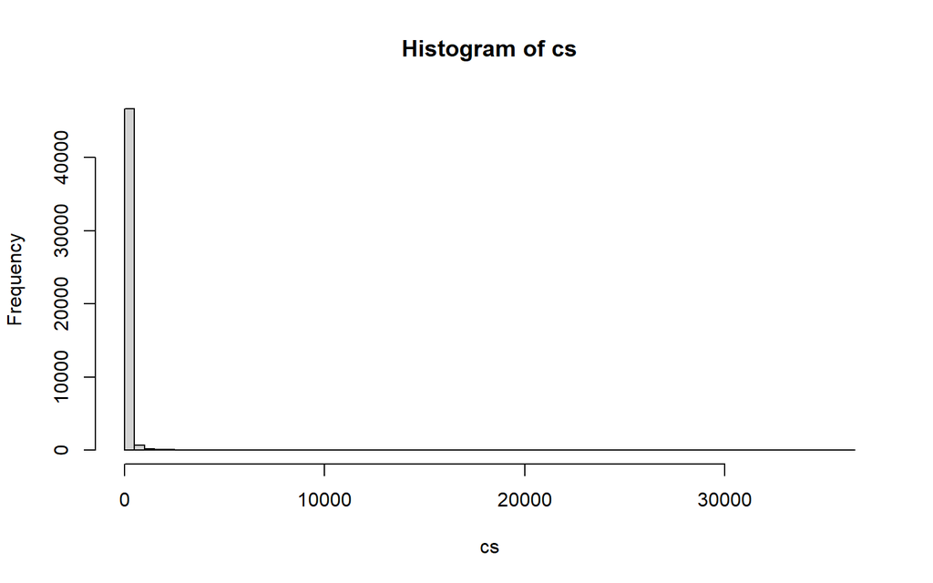

```r
cs <- as.matrix(colSums(m))             #How many times each term appears across all documents (texts)
rownames(cs) <- dtm_cleaned$dimnames$Terms

hist(cs, breaks=100)                    #Let's look at some histograms/tabulations/word cloud of total term appearance.
```

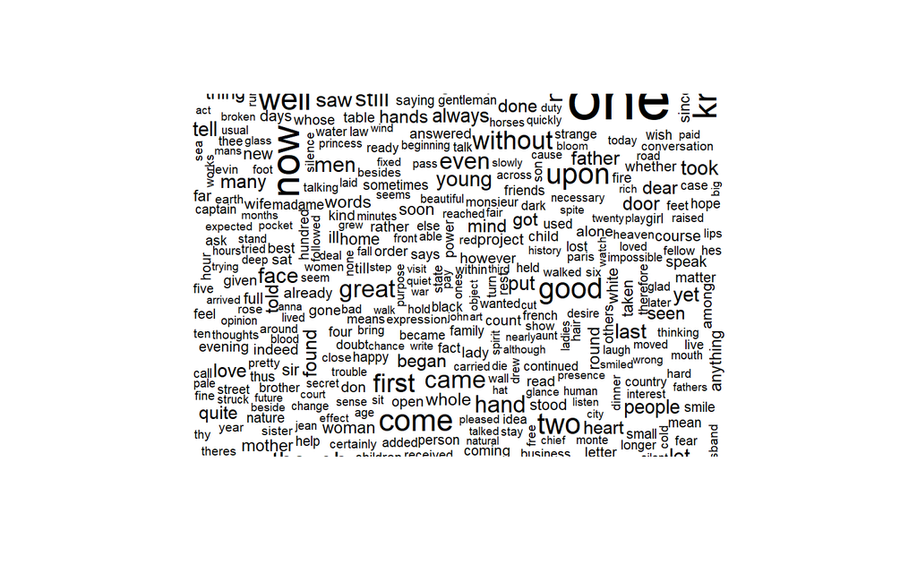

```r
tab <- as.matrix(table(cs))
wordcloud(myCorpus, min.freq=1000)
```

In our preparation for cluster analysis, let’s remove all variables where the column sum is less than 10,000 (i.e., if the term appears less than 10,000 times in all documents). We are only doing it here so that we have a reasonable number of variables to include in the cluster analysis for the sake of this example. If we were to have a lot more observations, we wouldn’t necessarily need or want to do this.

```r
variables_to_remove <- cs < 10000

# Subset matrix frame, excluding those variables
m_subset <- m[, !variables_to_remove]
```

Let’s do some additional data preparation for the cluster analysis.

```r
#Some books are longer, others are shorter. Let's divide the frequencies by the total number of words (after processing) in each book.
m_fin <- m_subset/rowSums(m)

#Let's scale (normalize) each of the variables (relative frequency)
m_scale <- scale(m_fin)
```

## Text Clustering

Of course, before performing the k-means analysis on the scaled (normalized) relative frequencies of words, we need to identify the optimal number of clusters. We do this using the Scree Plot and the `NbClust` package in R.

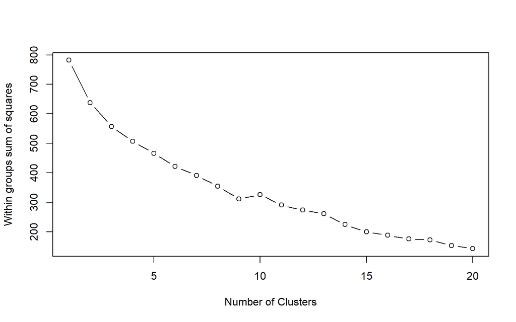

```r
#Scree Plot
wss <- (nrow(m_scale)-1)*sum(apply(m_scale,2,var))
for (i in 2:20) wss[i] <- sum(kmeans(m_scale,
                                     centers=i)$withinss)
plot(1:20, wss, type="b", xlab="Number of Clusters",
     ylab="Within groups sum of squares")
```

```r
#NbClust approach
set.seed(1234)
nc <- NbClust(m_scale, min.nc=2, max.nc=15, method="kmeans", index="all")
```

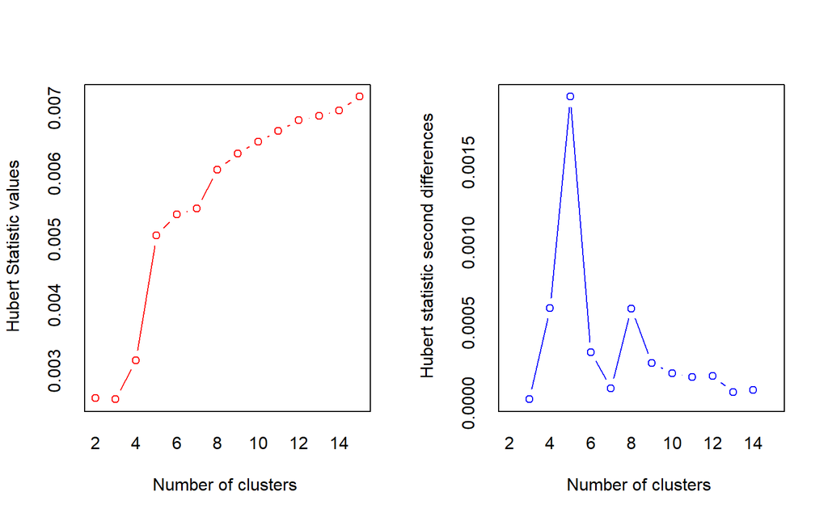

```
## *** : The Hubert index is a graphical method of determining the number of clusters.
##                 In the plot of Hubert index, we seek a significant knee that corresponds to a
##                 significant increase of the value of the measure i.e the significant peak in Hubert
##                 index second differences plot.
##
```

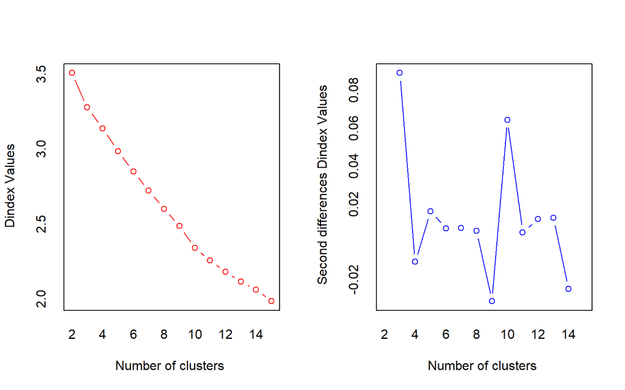

```
## *** : The D index is a graphical method of determining the number of clusters.
##                 In the plot of D index, we seek a significant knee (the significant peak in Dindex
##                 second differences plot) that corresponds to a significant increase of the value of
##                 the measure.
##
## * Among all indices:
## * 5 proposed 2 as the best number of clusters
## * 6 proposed 3 as the best number of clusters
## * 1 proposed 4 as the best number of clusters
## * 2 proposed 5 as the best number of clusters
## * 1 proposed 9 as the best number of clusters
## * 3 proposed 10 as the best number of clusters
## * 5 proposed 15 as the best number of clusters
##
##                    ***** Conclusion *****
##
## * According to the majority rule, the best number of clusters is  3
##
##
```

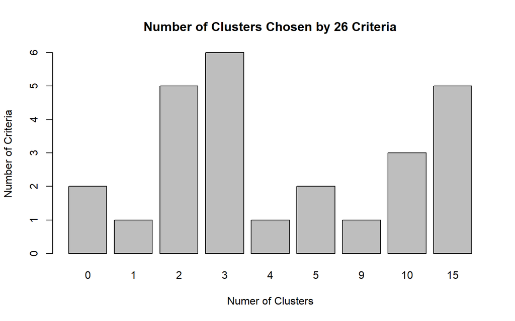

```r
#table(nc$Best.n[1,])
par(mfrow=c(1,1))
barplot(table(nc$Best.n[1,]),
        xlab="Numer of Clusters", ylab="Number of Criteria",
        main="Number of Clusters Chosen by 26 Criteria")
```

```r
k_means_results <- kmeans(m_scale, 2, 30)
```

```r
k_means_results$cluster
```

```
##          War and Peace   Crime and Punishment    Pride and Prejudice
##                      1                      1                      1
##     Tale of Two Cities                   Emma     Brothers Karamazov
##                      1                      1                      1
##              Jane Eyre       The Great Gatsby      Wuthering Heights
##                      1                      1                      1
##              Moby Dick       Call of the Wild           Frankenstein
##                      1                      1                      1
##           Little Women            Vanity Fair          Anna Karenina
##                      1                      1                      1
##  Count of Monte Cristo     Great Expectations         Les Miserables
##                      1                      1                      1
##                Dracula          Madame Bovary            Don Quixote
##                      1                      1                      1
##      Gullivers Travels       Huckleberry Finn Picture of Dorian Gray
##                      1                      2                      1
##             White Fang      A Christmas Carol              The Idiot
##                      1                      1                      1
##       The Time Machine       Age of Innocence       Of Human Bondage
##                      1                      1                      1
##          Paradise Lost        Robinson Crusoe                Candide
##                      1                      1                      1
##   Last of the Mohicans             Dead Souls         Scarlet Letter
##                      1                      1                      1
##        Treasure Island                Ulysses              The Trial
##                      1                      1                      1
##   The Three Musketeers      The Metamorphosis                  Faust
##                      1                      1                      1
##             The Prince              Leviathan      David Copperfield
##                      1                      1                      1
##    Notre Dame de Paris                 Utopia
##                      1                      1
```

```r
k_means_results$size
```

```
## [1] 46  1
```

Finally, let’s look at the number of times each of the terms appears in each cluster. We can also do this with proportions - that may make more sense. Ultimately, we see that certain terms have different frequencies in the clusters, but again, relative frequencies may be more relevant here.

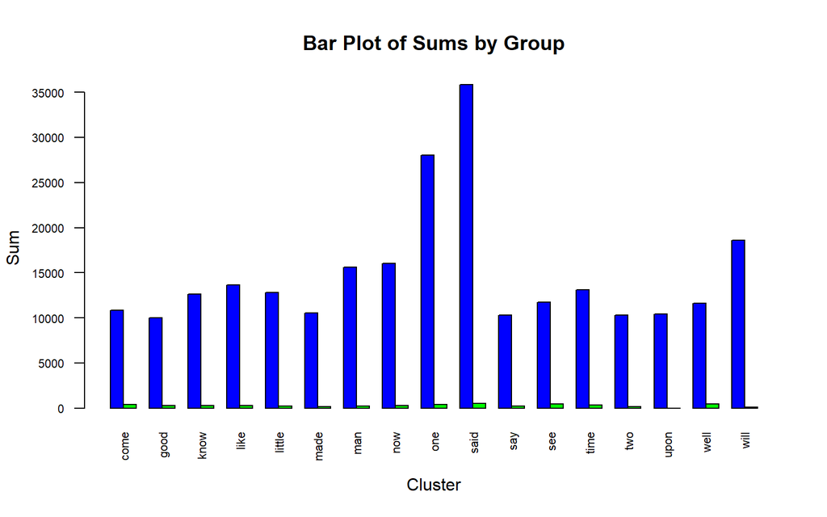

```r
word_totals_by_cluster <- round(aggregate(m_subset, by=list(cluster=k_means_results$cluster), sum),1)

#Let's plot the results!
#Decrease font size and rotate x-axis labels vertically
par(cex.axis = 0.7)  # Adjust the font size
par(las = 2)        # Rotate labels vertically

barplot(as.matrix(word_totals_by_cluster[-1]),
        beside = TRUE,
        col = c("blue", "green"),
        legend.text = TRUE,
        args.legend = list(x = "topright"))

# Add labels to the x-axis and y-axis. Here, the first cluster is in blue and the second one is in green.
title(xlab = "Cluster")
title(ylab = "Sum")

# Add a title to the plot
title(main = "Bar Plot of Sums by Group")
```

## Sentiment Analysis

The `syuzhet` package in R has several sentiment lexicons in it. A sentiment lexicon, also known as a sentiment dictionary, is a collection of words or phrases annotated with sentiment polarity information. It associates each word or phrase with a sentiment score indicating its positive, negative, or neutral sentiment. Sentiment lexicons are commonly used in sentiment analysis tasks to determine the sentiment or emotional tone expressed in text. A lot of the words are omitted from these lexicons, because they are neutral (e.g., *hair*, *purple*, *walk*).

The lexicons in the `syuzhet` package include:

1. NRC Lexicon: The NRC (National Research Council) lexicon is a sentiment lexicon included in the `syuzhet` package. It contains a comprehensive list of words annotated with different sentiment categories, such as positive, negative, anger, fear, joy, sadness, and more. The NRC lexicon enables sentiment analysis by associating words with specific emotional dimensions.
2. AFINN Lexicon: The AFINN lexicon is another sentiment lexicon available in `syuzhet`. It is based on a list of pre-computed sentiment scores for English words. Each word in the lexicon is assigned a score ranging from negative (-5) to positive (5), indicating its sentiment intensity. This lexicon is relatively simple and easy to use, making it popular for basic sentiment analysis tasks.
3. Bing Lexicon: The Bing lexicon, also known as the Bing Liu lexicon, is a sentiment lexicon provided by the `syuzhet` package. It consists of words categorized as either positive or negative based on their sentiment. The Bing lexicon is often used in sentiment analysis applications and can help in determining the polarity of text.
4. Syuzhet (Jockers) Lexicon: The Syuzhet lexicon is a sentiment lexicon specifically designed for the `syuzhet` package. It aims to capture sentiment by analyzing changes in the emotional intensity of a text over time. Unlike the NRC, AFINN, and Bing lexicons, the Syuzhet lexicon focuses on the temporal dynamics of sentiment, providing a unique perspective on the emotional trajectory within a piece of text. It may lend itself well to analyses presented here: https://www.tidytextmining.com/sentiment.html.

These lexicons within the `syuzhet` package offer different approaches to sentiment analysis, ranging from basic word-based scoring to more complex temporal sentiment analysis techniques. Each lexicon has its own strengths and characteristics, allowing users to choose the most suitable approach based on their specific needs and requirements.

We use sentiment analysis to examine the sentiment in an entire body of text. This is often done by aggregating (i.e., averaging or summing) sentiment scores of all the words in the text. One issue is that for longer texts, the positive and negative terms often tend to wash each other out. Therefore, shorter texts of a few sentences or paragraphs work well.

Another thing to keep in mind is that this approach doesn’t take into consideration the negative terms preceding a word (e.g., *NOT good*) or sarcasm (e.g., *I’m fired? Well that’s just GREAT!*). Additional data preprocessing may be necessary for this approach to work as intended, though we will skip it here. Note that removal of stop words and some of the other pre-processing done earlier is generally unnecessary for sentiment analysis, because a lot of these terms (e.g., *a*, *the*, *through*, *such*) are neutral terms and won’t affect the sentiment.

Let’s take a look at the four sentiment lexicons mentioned above. Here, we will print the first 20 terms of each of the lexicons.

```r
nrc <- syuzhet::get_sentiment_dictionary(dictionary="nrc")
head(nrc, n=20L)
```

```
##       lang           word sentiment value
## 1  english           abba  positive     1
## 2  english        ability  positive     1
## 3  english abovementioned  positive     1
## 4  english       absolute  positive     1
## 5  english     absolution  positive     1
## 6  english       absorbed  positive     1
## 7  english      abundance  positive     1
## 8  english       abundant  positive     1
## 9  english       academic  positive     1
## 10 english        academy  positive     1
## 11 english     acceptable  positive     1
## 12 english     acceptance  positive     1
## 13 english     accessible  positive     1
## 14 english       accolade  positive     1
## 15 english  accommodation  positive     1
## 16 english  accompaniment  positive     1
## 17 english     accomplish  positive     1
## 18 english   accomplished  positive     1
## 19 english accomplishment  positive     1
## 20 english         accord  positive     1
```

```r
afinn <- syuzhet::get_sentiment_dictionary(dictionary="afinn")
head(afinn, n=20L)
```

```
##          word value
## 1     abandon    -2
## 2   abandoned    -2
## 3    abandons    -2
## 4    abducted    -2
## 5   abduction    -2
## 6  abductions    -2
## 7       abhor    -3
## 8    abhorred    -3
## 9   abhorrent    -3
## 10     abhors    -3
## 11  abilities     2
## 12    ability     2
## 13     aboard     1
## 14    aborted    -1
## 15     aborts    -1
## 16   absentee    -1
## 17  absentees    -1
## 18    absolve     2
## 19   absolved     2
## 20   absolves     2
```

```r
bing <- syuzhet::get_sentiment_dictionary(dictionary="bing")
head(bing, n=20L)
```

```
##               word value
## 1               a+     1
## 2           abound     1
## 3          abounds     1
## 4        abundance     1
## 5         abundant     1
## 6       accessable     1
## 7       accessible     1
## 8          acclaim     1
## 9        acclaimed     1
## 10     acclamation     1
## 11        accolade     1
## 12       accolades     1
## 13   accommodative     1
## 14    accomodative     1
## 15      accomplish     1
## 16    accomplished     1
## 17  accomplishment     1
## 18 accomplishments     1
## 19        accurate     1
## 20      accurately     1
```

```r
syuzhet <- syuzhet::get_sentiment_dictionary(dictionary="syuzhet")
head(syuzhet, n=20L)
```

```
##           word value
## 1      abandon -0.75
## 2    abandoned -0.50
## 3    abandoner -0.25
## 4  abandonment -0.25
## 5     abandons -1.00
## 6     abducted -1.00
## 7    abduction -0.50
## 8   abductions -1.00
## 9     aberrant -0.60
## 10  aberration -0.80
## 11       abhor -0.50
## 12    abhorred -1.00
## 13   abhorrent -0.50
## 14      abhors -1.00
## 15   abilities  0.60
## 16     ability  0.50
## 17      abject -1.00
## 18      ablaze -0.25
## 19    abnormal -0.50
## 20      aboard  0.25
```

Now, let’s play around with the `nrc` lexicon. First, we can get the sentiment for any term, e.g., gorgeous.

```r
get_nrc_sentiment("gorgeous")
```

```
##   anger anticipation disgust fear joy sadness surprise trust negative positive
## 1     0            0       0    0   1       0        0     0        0        1
```

Now, let’s go back to our book example. For the sake of this lexicon, let’s take the first book in our data, War And Peace, which is the first row of the matrix `m`. The `get_nrc_sentiment` command obtains the sentiment score for each word in War And Peace that wasn’t removed in the cleaning process above.

```r
War_And_Peace <- as.data.frame(m[1,])
War_And_Peace$Term <- as.vector(rownames(War_And_Peace))
colnames(War_And_Peace)[1] = "Term_Frequency"
rownames(War_And_Peace) <- 1:nrow(War_And_Peace)

nrc_sentiment <- get_nrc_sentiment(War_And_Peace$Term)
```

Let’s combine the original data frame and the sentiment counts.

```r
War_And_Peace_Sentiment <- cbind(War_And_Peace, nrc_sentiment)
```

Now let’s multiply the sentiment by the frequency of the term.

```r
# Select the columns to be multiplied (last ten columns)
cols_to_multiply <- names(War_And_Peace_Sentiment)[3:12]

# Multiply the last ten columns (sentiments) by the first column (Term_Frequency)
War_And_Peace_Sentiment[, cols_to_multiply] <- War_And_Peace_Sentiment[, cols_to_multiply] * War_And_Peace_Sentiment$Term_Frequency
```

Now, let’s see the total prevalence of each sentiment in the text by summing each column and creating a bar plot

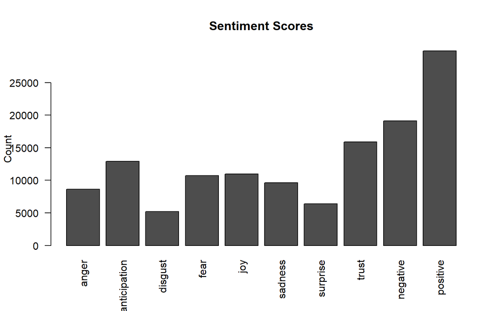

```r
War_And_Peace_Sentiment_Total <- t(as.matrix(colSums(War_And_Peace_Sentiment[,-1:-2])))
barplot(War_And_Peace_Sentiment_Total, las=2, ylab='Count', main='Sentiment Scores')
```

Note that this can be done for each of the books, and then the total sentiment scores (ideally, weighted by the number of terms in each book and then normalized) can be subjected to a cluster analysis. This way, we can see if we can group the books based on the sentiments expressed, rather than the most frequently occurring terms themselves. This will be skipped in this Markdown.

Now, let’s play around with some of the other lexicons. Specifically, we will use the `get_sentiment` command to get the scores for each of the terms using each dictionary, and save the output to the original `War_And_Peace` data frame.

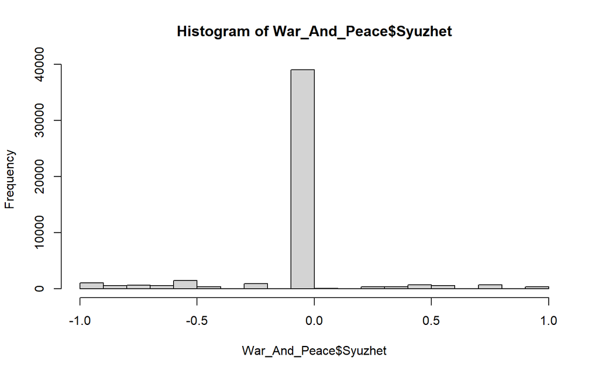

```r
War_And_Peace$Syuzhet <- as.matrix(get_sentiment(War_And_Peace$Term, method="syuzhet"))
hist(War_And_Peace$Syuzhet)
```

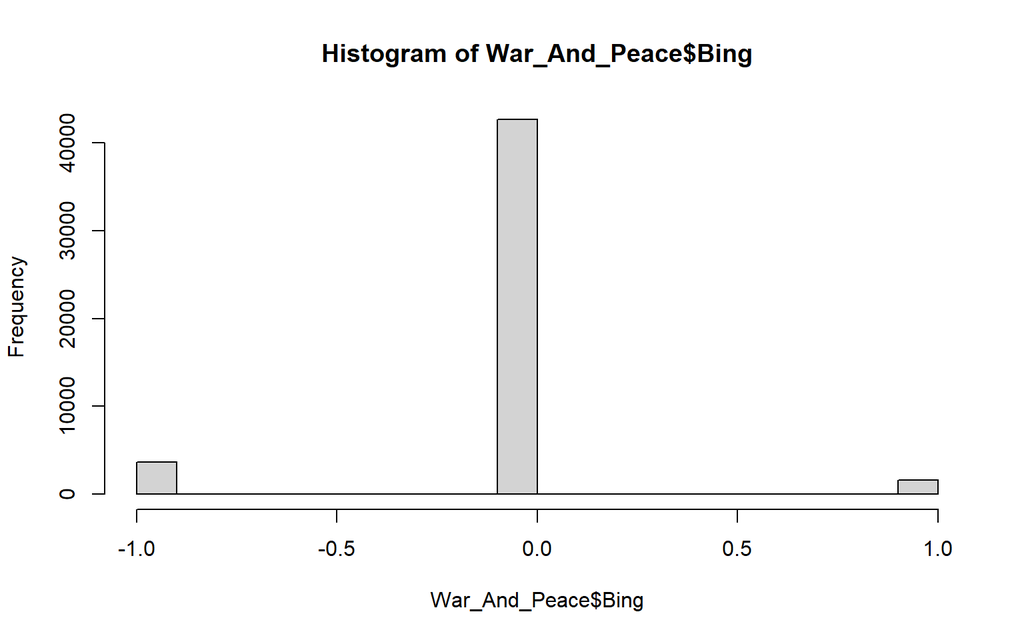

```r
War_And_Peace$Bing <- as.matrix(get_sentiment(War_And_Peace$Term, method="bing"))
hist(War_And_Peace$Bing)
```

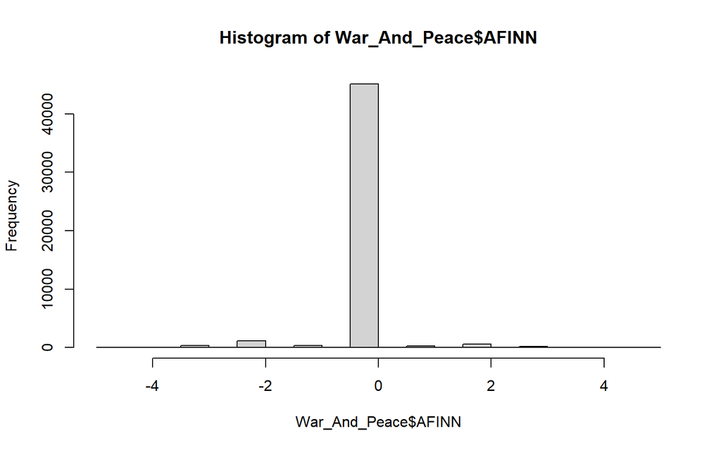

```r
War_And_Peace$AFINN <- as.matrix(get_sentiment(War_And_Peace$Term, method="afinn"))
hist(War_And_Peace$AFINN)
```

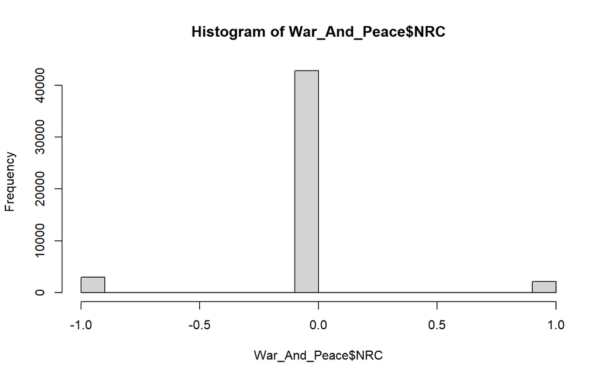

```r
War_And_Peace$NRC <- as.matrix(get_sentiment(War_And_Peace$Term, method="nrc"))   #There are Negative and Positive sentiments in the NRC output above.
hist(War_And_Peace$NRC)
```

We can compare the results from the different lexicons by assigning a value of -1 to all terms that have a negative sentiment, 0 to all terms that have a neutral sentiment, and 1 to all terms that have a positive sentiment.

```r
sentiment_columns <- War_And_Peace[ , 3:6]
sentiment_columns <- data.frame(lapply(sentiment_columns, sign))
sentiment_columns <- data.frame(lapply(sentiment_columns, as.factor))
```

Now, let’s see the prevalence of *unique* negative, neutral terms (here, we are talking about *unique* terms because we are not weighing them by how often they appear in the document).

```r
#Raw frequencies
sapply(sentiment_columns, function(x) if("factor" %in% class(x)) {table(x)})
```

```
##    Syuzhet  Bing AFINN   NRC
## -1    5744  3645  1769  2989
## 0    38972 42635 45099 42754
## 1     3159  1595  1007  2132
```

```r
#Proportions
sapply(sentiment_columns, function(x) if("factor" %in% class(x)) {prop.table(table(x))})
```

```
##       Syuzhet       Bing      AFINN        NRC
## -1 0.11997911 0.07613577 0.03695039 0.06243342
## 0  0.81403655 0.89054830 0.94201567 0.89303394
## 1  0.06598433 0.03331593 0.02103394 0.04453264
```

We can see that in general, most of the terms are neutral, with about 2-6% of terms being positive and 4-12% of the terms being negative, depending on which lexicon we use.

## References

1. Hill, Chelsey. 2023. “Sentiment Analysis (Lexicons)”. Rstudio-Pubs-Static.S3.Amazonaws.Com. https://rstudio-pubs-static.s3.amazonaws.com/676279_2fa8c2a7a3da4e7089e24442758e9d1b.html.
2. “Sentiment Analysis In R | R-Bloggers”. 2021. R-Bloggers. https://www.r-bloggers.com/2021/05/sentiment-analysis-in-r-3/.
3. Robinson, Julia. 2023. “2 Sentiment Analysis With Tidy Data | Text Mining With R”. Tidytextmining.Com. https://www.tidytextmining.com/sentiment.html.
4. “Text Mining: Sentiment Analysis · AFIT Data Science Lab R Programming Guide”. 2023. Afit-R.Github.Io. https://afit-r.github.io/sentiment_analysis.
5. “TDM (Term Document Matrix) And DTM (Document Term Matrix)”. 2023. Medium. https://medium.com/analytics-vidhya/tdm-term-document-matrix-and-dtm-document-term-matrix-8b07c58957e2.
6. “Text Clustering With R: An Introduction For Data Scientists”. 2018. Medium. https://medium.com/@SAPCAI/text-clustering-with-r-an-introduction-for-data-scientists-c406e7454e76.
7. “Introductory Tutorial To Text Clustering With R”. 2023. Rstudio-Pubs-Static.S3.Amazonaws.Com. https://rstudio-pubs-static.s3.amazonaws.com/445820_c6663e5a79874afdae826669a9499413.html.
8. “Library Guides: Text Mining & Text Analysis: Language Corpora”. 2023. Guides.Library.Uq.Edu.Au. https://guides.library.uq.edu.au/research-techniques/text-mining-analysis/language-corpora.